# Consistencia multi-cohorte: genes comunes en tumor

TFM Melanoma Inmunoterapia

2026-05-12

# 1 Objetivo

Este informe evalúa la **consistencia** de los efectos transcriptómicos entre respondedores y no respondedores en las tres cohortes tumorales, limitándose a los **genes comunes** presentes en todos los paneles.

El análisis es complementario al descubrimiento en GSE78220 (transcriptoma completo): aquí la pregunta no es descubrir genes nuevos, sino comprobar si la dirección del efecto observada en GSE78220 se reproduce en GSE215868 y GSE211645 con el subconjunto de genes que comparten las tres cohortes.

## 1.1 Ficha del informe

| Elemento | Detalle |
| --- | --- |
| Genes analizados | 200 genes comunes (intersección de paneles NanoString y RNA-seq) |
| Cohorte 1 | GSE78220 — RNA-seq, tumor, anti-PD-1 |
| Cohorte 2 | GSE215868 — NanoString, tumor, anti-PD-1 |
| Cohorte 3 | GSE211645 — NanoString, tumor, anti-CTLA-4 |
| Escala de expresión | GSE78220: log2(TPM+1); GSE215868/GSE211645: log-NanoString (ya normalizado) |
| Salida | `resultados/consistency_integrated/` |
| Interpretación | La dirección del logFC es comparable entre cohortes; la magnitud no lo es (escalas distintas) |

# 2 Librerías

```r
required_packages <- c(
  "SummarizedExperiment", "limma", "dplyr", "tibble",
  "ggplot2", "knitr", "matrixStats", "tidyr", "here", "pheatmap", "purrr"
)

for (pkg in required_packages) {
  if (!requireNamespace(pkg, quietly = TRUE)) {
    stop(paste("Falta instalar el paquete:", pkg))
  }
}

library(SummarizedExperiment)
library(limma)
library(dplyr)
library(tibble)
library(ggplot2)
library(knitr)
library(matrixStats)
library(tidyr)
library(here)
library(pheatmap)
library(purrr)
```

# 3 Rutas y carga

```r
project_root <- here::here()
output_dir   <- file.path(project_root, "resultados", "consistency_integrated")
dir.create(output_dir, recursive = TRUE, showWarnings = FALSE)

# Objeto integrado — solo para extraer la lista de genes comunes
integrated_path <- file.path(project_root, "integrated_dataset",
                              "se_integrated_geo_tumor.rds")

# Objetos individuales por cohorte
se_paths <- c(
  GSE78220  = file.path(project_root, "SummarizedExperiment_objects", "se_gse78220.rds"),
  GSE215868 = file.path(project_root, "SummarizedExperiment_objects", "se_gse215868.rds"),
  GSE211645 = file.path(project_root, "SummarizedExperiment_objects", "se_gse211645.rds")
)

# Resultados del descubrimiento (transcriptoma completo GSE78220)
discovery_path <- file.path(project_root, "resultados", "discovery_GSE78220",
                             "GSE78220_DEA_limma_response.csv")

stopifnot(file.exists(integrated_path))
stopifnot(all(file.exists(se_paths)))
stopifnot(file.exists(discovery_path))

se_integrated <- readRDS(integrated_path)
se_list       <- lapply(se_paths, readRDS)
discovery     <- read.csv(discovery_path)

cat("Objeto integrado — genes comunes:", nrow(se_integrated), "\n")
```

```
## Objeto integrado — genes comunes: 200
```

```r
cat("Muestras integradas:", ncol(se_integrated), "\n")
```

```
## Muestras integradas: 170
```

# 4 Genes comunes e información de plataformas

```r
common_genes <- rownames(se_integrated)
cat("Total genes comunes:", length(common_genes), "\n")
```

```
## Total genes comunes: 200
```

```r
platform_summary <- imap_dfr(se_list, function(se_obj, dataset_name) {
  cd <- as.data.frame(colData(se_obj))
  tibble(
    dataset   = dataset_name,
    platform  = paste(unique(cd$platform), collapse = ", "),
    n_genes_original = nrow(se_obj),
    n_genes_comunes  = sum(rownames(se_obj) %in% common_genes |
                           as.character(rowData(se_obj)$gene_symbol) %in% common_genes),
    n_samples = ncol(se_obj)
  )
})

kable(platform_summary, caption = "Cohortes y genes comunes disponibles")
```

Cohortes y genes comunes disponibles

| dataset | platform | n_genes_original | n_genes_comunes | n_samples |
| --- | --- | --- | --- | --- |
| GSE78220 | RNA-seq | 25268 | 200 | 25 |
| GSE215868 | NanoString | 770 | 200 | 105 |
| GSE211645 | GPL32584 | 418 | 200 | 40 |

# 5 Funciones auxiliares

```r
# Nota sobre escalas: GSE78220 almacena TPM lineal → aplicar log2(x+1).
# GSE215868 y GSE211645 son NanoString ya en escala log (rango típico -4 a 20).
# La dirección del logFC es comparable entre cohortes; la magnitud no.

derive_response <- function(response_raw, response_binary = NULL) {
  resp <- as.character(response_binary)
  raw  <- toupper(trimws(as.character(response_raw)))

  resp[is.na(resp) | resp == ""] <- NA_character_
  resp[is.na(resp) & grepl("^CR|^PR|COMPLETE|PARTIAL|PRCR", raw)] <- "Responder"
  resp[is.na(resp) & grepl("^PD|^SD|PROGRESS|STABLE",       raw)] <- "No_responder"
  resp[grepl("^UK|^UNK|UNKNOWN|^NA$", raw)]                        <- NA_character_

  factor(resp, levels = c("No_responder", "Responder"))
}

prepare_cohort <- function(se_obj, dataset_name, common_genes) {
  cd <- as.data.frame(colData(se_obj))

  # Identificar gene_symbol
  rd <- as.data.frame(rowData(se_obj))
  gene_col <- if ("gene_symbol" %in% names(rd)) rd$gene_symbol else rownames(se_obj)
  gene_col  <- toupper(trimws(as.character(gene_col)))

  # Extraer y ordenar expresión
  expr <- assay(se_obj, if ("expr" %in% assayNames(se_obj)) "expr" else assayNames(se_obj)[1])
  expr <- as.matrix(expr)
  mode(expr) <- "numeric"
  rownames(expr) <- gene_col

  # Colapsar duplicados por media antes de filtrar
  if (anyDuplicated(rownames(expr))) {
    expr_df <- as.data.frame(expr, check.names = FALSE)
    expr_df$gene <- rownames(expr)
    expr_df <- expr_df %>%
      group_by(gene) %>%
      summarise(across(where(is.numeric), ~ mean(.x, na.rm = TRUE)), .groups = "drop")
    genes_tmp <- expr_df$gene
    expr <- as.matrix(expr_df[, -1, drop = FALSE])
    rownames(expr) <- genes_tmp
  }

  # Restringir a genes comunes
  genes_present <- intersect(common_genes, rownames(expr))
  expr <- expr[genes_present, , drop = FALSE]

  # Transformación logarítmica solo para RNA-seq (TPM lineal)
  if (dataset_name == "GSE78220") {
    expr <- log2(expr + 1)
  }

  # Respuesta
  response <- derive_response(cd$response_raw, cd$response_binary)

  list(
    dataset      = dataset_name,
    expr         = expr,
    response     = response,
    genes_used   = genes_present,
    n_genes      = length(genes_present),
    n_responder  = sum(response == "Responder",    na.rm = TRUE),
    n_no_resp    = sum(response == "No_responder", na.rm = TRUE),
    n_na         = sum(is.na(response))
  )
}

run_limma_cohort <- function(cohort_data) {
  expr     <- cohort_data$expr
  response <- cohort_data$response

  # Filtrar NAs de respuesta
  keep <- !is.na(response)
  expr     <- expr[, keep, drop = FALSE]
  response <- droplevels(response[keep])

  if (nlevels(response) != 2) {
    message("Solo un nivel de respuesta en ", cohort_data$dataset, " — DEA omitido.")
    return(NULL)
  }

  # Genes sin varianza suficiente
  zero_var <- matrixStats::rowVars(expr, na.rm = TRUE) == 0
  expr <- expr[!zero_var, , drop = FALSE]

  design   <- model.matrix(~ 0 + response)
  colnames(design) <- make.names(colnames(design))

  contrast <- makeContrasts(responseResponder - responseNo_responder, levels = design)

  fit  <- lmFit(expr, design)
  fit2 <- contrasts.fit(fit, contrast)
  fit2 <- eBayes(fit2)

  topTable(fit2, coef = 1, number = Inf, adjust.method = "BH", sort.by = "none") %>%
    rownames_to_column("gene") %>%
    arrange(P.Value)
}
```

# 6 Preparación y DEA por cohorte

```r
cohorts <- imap(se_list, prepare_cohort, common_genes = common_genes)

cohort_summary <- imap_dfr(cohorts, function(co, nm) {
  tibble(
    dataset     = nm,
    genes_comunes_disponibles = co$n_genes,
    n_responder   = co$n_responder,
    n_no_responder = co$n_no_resp,
    n_na_response = co$n_na
  )
})

kable(cohort_summary, caption = "Muestras y genes por cohorte tras restricción a genes comunes")
```

Muestras y genes por cohorte tras restricción a genes comunes

| dataset | genes_comunes_disponibles | n_responder | n_no_responder | n_na_response |
| --- | --- | --- | --- | --- |
| GSE78220 | 200 | 13 | 12 | 0 |
| GSE215868 | 200 | 45 | 59 | 1 |
| GSE211645 | 200 | 12 | 28 | 0 |

```r
dea_list <- lapply(cohorts, run_limma_cohort)

# Guardar DEAs individuales
iwalk(dea_list, function(res, nm) {
  if (!is.null(res)) {
    write.csv(res, file.path(output_dir, paste0(nm, "_DEA_common_genes.csv")), row.names = FALSE)
  }
})

# Resumen por cohorte
dea_summary <- imap_dfr(dea_list, function(res, nm) {
  if (is.null(res)) return(tibble(dataset = nm, n_genes_testados = 0,
                                   n_nominal_P05 = 0, n_fdr_05 = 0))
  tibble(
    dataset          = nm,
    n_genes_testados = nrow(res),
    n_nominal_P05    = sum(res$P.Value < 0.05 & abs(res$logFC) >= 0.5, na.rm = TRUE),
    n_fdr_05         = sum(res$adj.P.Val < 0.05 & abs(res$logFC) >= 0.5, na.rm = TRUE)
  )
})

kable(dea_summary, caption = "Resumen DEA por cohorte (genes comunes)")
```

Resumen DEA por cohorte (genes comunes)

| dataset | n_genes_testados | n_nominal_P05 | n_fdr_05 |
| --- | --- | --- | --- |
| GSE78220 | 200 | 6 | 0 |
| GSE215868 | 200 | 20 | 0 |
| GSE211645 | 200 | 103 | 85 |

# 7 Tabla cruzada de logFC y dirección

```r
# Construir tabla con logFC y P de cada cohorte para cada gen
build_cross_table <- function(dea_list, common_genes) {
  dfs <- imap(dea_list, function(res, nm) {
    if (is.null(res)) {
      tibble(gene = common_genes,
             !!paste0("logFC_", nm)   := NA_real_,
             !!paste0("P_", nm)       := NA_real_,
             !!paste0("adjP_", nm)    := NA_real_)
    } else {
      res %>%
        select(gene,
               !!paste0("logFC_", nm) := logFC,
               !!paste0("P_", nm)     := P.Value,
               !!paste0("adjP_", nm)  := adj.P.Val)
    }
  })

  Reduce(function(a, b) full_join(a, b, by = "gene"), dfs)
}

cross_table <- build_cross_table(dea_list, common_genes)

# Concordancia de dirección (solo cohorts con datos)
cohorts_with_data <- names(dea_list)[!sapply(dea_list, is.null)]
logfc_cols <- paste0("logFC_", cohorts_with_data)

cross_table <- cross_table %>%
  mutate(
    n_cohorts_up   = rowSums(across(all_of(logfc_cols), ~ .x > 0), na.rm = TRUE),
    n_cohorts_down = rowSums(across(all_of(logfc_cols), ~ .x < 0), na.rm = TRUE),
    n_cohorts_tested = rowSums(across(all_of(logfc_cols), ~ !is.na(.x))),
    direction_concordant = case_when(
      n_cohorts_up   == n_cohorts_tested ~ "Up en todas",
      n_cohorts_down == n_cohorts_tested ~ "Down en todas",
      n_cohorts_tested == 1              ~ "Solo 1 cohorte",
      TRUE                               ~ "Discordante"
    )
  )

# Cross-referencia con discovery (transcriptoma completo)
discovery_top50 <- discovery %>%
  arrange(P.Value) %>%
  slice_head(n = 50) %>%
  mutate(gene = toupper(gene)) %>%
  pull(gene)

discovery_top100 <- discovery %>%
  arrange(P.Value) %>%
  slice_head(n = 100) %>%
  mutate(gene = toupper(gene)) %>%
  pull(gene)

cross_table <- cross_table %>%
  mutate(
    in_discovery_top50  = gene %in% discovery_top50,
    in_discovery_top100 = gene %in% discovery_top100
  ) %>%
  arrange(
    desc(in_discovery_top50),
    desc(in_discovery_top100),
    desc(n_cohorts_up + n_cohorts_down)
  )

write.csv(cross_table, file.path(output_dir, "cross_cohort_logFC_table.csv"), row.names = FALSE)

cat("Genes en top 50 del descubrimiento presentes en los genes comunes:",
    sum(cross_table$in_discovery_top50), "\n")
```

```
## Genes en top 50 del descubrimiento presentes en los genes comunes: 1
```

```r
cat("Genes en top 100 del descubrimiento presentes en los genes comunes:",
    sum(cross_table$in_discovery_top100), "\n")
```

```
## Genes en top 100 del descubrimiento presentes en los genes comunes: 2
```

## 7.1 Tabla resumen por dirección de efecto

```r
cross_table %>%
  count(direction_concordant, name = "n_genes") %>%
  arrange(desc(n_genes)) %>%
  kable(caption = "Concordancia de dirección del efecto en los genes comunes")
```

Concordancia de dirección del efecto en los genes comunes

| direction_concordant | n_genes |
| --- | --- |
| Discordante | 131 |
| Up en todas | 61 |
| Down en todas | 8 |

## 7.2 Top genes con dirección concordante en todas las cohortes

```r
concordant_all <- cross_table %>%
  filter(direction_concordant %in% c("Up en todas", "Down en todas")) %>%
  select(gene, starts_with("logFC_"), starts_with("P_"), direction_concordant,
         in_discovery_top50, in_discovery_top100) %>%
  mutate(min_P = pmin(P_GSE78220, P_GSE215868, P_GSE211645, na.rm = TRUE)) %>%
  arrange(direction_concordant, min_P)

cat("Genes concordantes en todas las cohortes testadas:", nrow(concordant_all), "\n")
```

```
## Genes concordantes en todas las cohortes testadas: 69
```

```r
concordant_all %>%
  head(40) %>%
  kable(digits = 3, caption = "Genes con dirección concordante en todas las cohortes")
```

Genes con dirección concordante en todas las cohortes

| gene | logFC_GSE78220 | logFC_GSE215868 | logFC_GSE211645 | P_GSE78220 | P_GSE215868 | P_GSE211645 | direction_concordant | in_discovery_top50 | in_discovery_top100 | min_P |
| --- | --- | --- | --- | --- | --- | --- | --- | --- | --- | --- |
| ITGB3 | -0.009 | -0.359 | -2.059 | 0.992 | 0.287 | 0.001 | Down en todas | FALSE | FALSE | 0.001 |
| VCAN | -1.789 | -0.363 | -0.017 | 0.009 | 0.123 | 0.971 | Down en todas | FALSE | TRUE | 0.009 |
| CDH5 | -0.446 | -0.056 | -0.387 | 0.166 | 0.773 | 0.276 | Down en todas | FALSE | FALSE | 0.166 |
| VCAM1 | -0.614 | -0.037 | -0.216 | 0.228 | 0.876 | 0.561 | Down en todas | FALSE | FALSE | 0.228 |
| GNG4 | -0.531 | -0.060 | -0.277 | 0.252 | 0.760 | 0.623 | Down en todas | FALSE | FALSE | 0.252 |
| CD276 | -0.372 | -0.120 | -0.087 | 0.285 | 0.396 | 0.756 | Down en todas | FALSE | FALSE | 0.285 |
| TLK2 | -0.042 | -0.071 | -0.144 | 0.841 | 0.427 | 0.472 | Down en todas | FALSE | FALSE | 0.427 |
| CXCL14 | -0.529 | -0.387 | -0.349 | 0.565 | 0.450 | 0.690 | Down en todas | FALSE | FALSE | 0.450 |
| HLA-DPA1 | 0.194 | 0.373 | 2.099 | 0.686 | 0.137 | 0.000 | Up en todas | FALSE | FALSE | 0.000 |
| HLA-DQA1 | 0.625 | 1.149 | 2.573 | 0.452 | 0.165 | 0.000 | Up en todas | FALSE | FALSE | 0.000 |
| HLA-F | 0.473 | 0.633 | 1.620 | 0.357 | 0.008 | 0.000 | Up en todas | FALSE | FALSE | 0.000 |
| LY9 | 0.023 | 0.113 | 2.372 | 0.956 | 0.688 | 0.000 | Up en todas | FALSE | FALSE | 0.000 |
| IRF8 | 0.119 | 0.232 | 1.744 | 0.836 | 0.329 | 0.000 | Up en todas | FALSE | FALSE | 0.000 |
| HLA-A | 1.062 | 0.187 | 1.564 | 0.259 | 0.607 | 0.000 | Up en todas | FALSE | FALSE | 0.000 |
| CD74 | 0.227 | 0.481 | 2.160 | 0.670 | 0.052 | 0.000 | Up en todas | FALSE | FALSE | 0.000 |
| CXCR4 | 0.093 | 0.101 | 2.108 | 0.864 | 0.685 | 0.000 | Up en todas | FALSE | FALSE | 0.000 |
| HLA-E | 0.450 | 0.336 | 1.428 | 0.259 | 0.066 | 0.000 | Up en todas | FALSE | FALSE | 0.000 |
| CD27 | 0.014 | 0.297 | 2.357 | 0.982 | 0.327 | 0.000 | Up en todas | FALSE | FALSE | 0.000 |
| IL32 | 0.081 | 0.277 | 1.908 | 0.899 | 0.240 | 0.000 | Up en todas | FALSE | FALSE | 0.000 |
| IL2RG | 0.003 | 0.437 | 1.739 | 0.996 | 0.110 | 0.000 | Up en todas | FALSE | FALSE | 0.000 |
| CD274 | 0.109 | 0.625 | 1.768 | 0.794 | 0.011 | 0.001 | Up en todas | FALSE | FALSE | 0.001 |
| ITGAX | 0.162 | 0.368 | 2.056 | 0.654 | 0.046 | 0.001 | Up en todas | FALSE | FALSE | 0.001 |
| HLA-DRB1 | 0.474 | 0.502 | 1.700 | 0.669 | 0.079 | 0.001 | Up en todas | FALSE | FALSE | 0.001 |
| ICOS | 0.038 | 0.281 | 1.609 | 0.912 | 0.228 | 0.001 | Up en todas | FALSE | FALSE | 0.001 |
| PSMB8 | 0.420 | 0.613 | 0.527 | 0.238 | 0.002 | 0.055 | Up en todas | FALSE | FALSE | 0.002 |
| LCK | 0.080 | 0.380 | 1.651 | 0.885 | 0.159 | 0.002 | Up en todas | FALSE | FALSE | 0.002 |
| NLRC5 | 0.100 | 0.511 | 1.044 | 0.757 | 0.021 | 0.002 | Up en todas | FALSE | FALSE | 0.002 |
| CD5 | 0.096 | 0.318 | 1.863 | 0.809 | 0.120 | 0.002 | Up en todas | FALSE | FALSE | 0.002 |
| PSMB9 | 0.221 | 0.682 | 1.131 | 0.623 | 0.004 | 0.003 | Up en todas | FALSE | FALSE | 0.003 |
| CSF2 | 0.023 | 0.258 | 2.156 | 0.895 | 0.253 | 0.004 | Up en todas | FALSE | FALSE | 0.004 |
| TNFAIP3 | 0.318 | 0.097 | 0.953 | 0.441 | 0.679 | 0.004 | Up en todas | FALSE | FALSE | 0.004 |
| HLA-B | 0.636 | 0.667 | 1.216 | 0.320 | 0.005 | 0.007 | Up en todas | FALSE | FALSE | 0.005 |
| TAP1 | 0.181 | 0.652 | 0.537 | 0.635 | 0.005 | 0.366 | Up en todas | FALSE | FALSE | 0.005 |
| SLAMF7 | 0.538 | 0.468 | 1.392 | 0.407 | 0.107 | 0.005 | Up en todas | FALSE | FALSE | 0.005 |
| CD40 | 0.028 | 0.255 | 1.093 | 0.952 | 0.167 | 0.005 | Up en todas | FALSE | FALSE | 0.005 |
| PSMB10 | 0.238 | 0.486 | 0.946 | 0.594 | 0.006 | 0.020 | Up en todas | FALSE | FALSE | 0.006 |
| B2M | 0.222 | 0.537 | 0.845 | 0.582 | 0.006 | 0.012 | Up en todas | FALSE | FALSE | 0.006 |
| HLA-C | 0.878 | 0.594 | 1.235 | 0.179 | 0.020 | 0.007 | Up en todas | FALSE | FALSE | 0.007 |
| CXCL16 | 0.004 | 0.160 | 1.420 | 0.991 | 0.376 | 0.007 | Up en todas | FALSE | FALSE | 0.007 |
| BTLA | 0.084 | 0.127 | 1.255 | 0.788 | 0.657 | 0.009 | Up en todas | FALSE | FALSE | 0.009 |

## 7.3 Genes del top 50 discovery presentes en los genes comunes

```r
cross_table %>%
  filter(in_discovery_top50) %>%
  select(gene, starts_with("logFC_"), starts_with("P_"), direction_concordant) %>%
  kable(digits = 3,
        caption = "Top 50 genes discovery (GSE78220 completo) que aparecen en los genes comunes")
```

Top 50 genes discovery (GSE78220 completo) que aparecen en los genes comunes

| gene | logFC_GSE78220 | logFC_GSE215868 | logFC_GSE211645 | P_GSE78220 | P_GSE215868 | P_GSE211645 | direction_concordant |
| --- | --- | --- | --- | --- | --- | --- | --- |
| AXL | -1.409 | 0.154 | 1.11 | 0.002 | 0.459 | 0.008 | Discordante |

# 8 Visualización

## 8.1 Heatmap de logFC por gen y cohorte

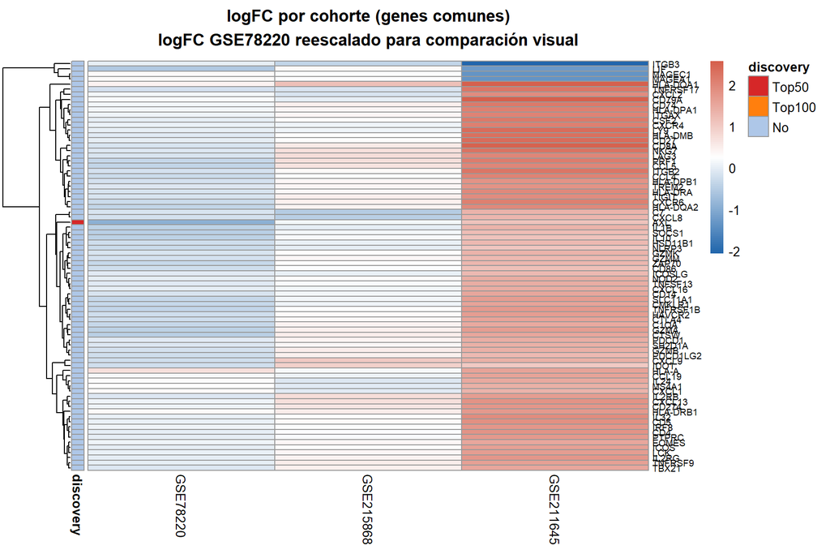

```r
# Seleccionar genes informativos: varianza de logFC > 0 entre cohortes
logfc_mat <- cross_table %>%
  filter(!is.na(logFC_GSE78220) | !is.na(logFC_GSE215868)) %>%
  select(gene, all_of(logfc_cols)) %>%
  column_to_rownames("gene") %>%
  as.matrix()

# Eliminar filas con todos NA
logfc_mat <- logfc_mat[rowSums(!is.na(logfc_mat)) >= 2, , drop = FALSE]

# Normalizar logFC de GSE78220 a rango similar al NanoString para comparar visual
# (solo para el heatmap; la tabla original conserva los valores reales)
scale_to_range <- function(x, ref) {
  if (all(is.na(x))) return(x)
  sd_ref <- sd(ref, na.rm = TRUE)
  sd_x   <- sd(x,   na.rm = TRUE)
  if (sd_x == 0 || is.na(sd_x)) return(x)
  x * (sd_ref / sd_x)
}

logfc_display <- logfc_mat
if ("logFC_GSE78220" %in% colnames(logfc_display) && ncol(logfc_display) > 1) {
  ref_col <- setdiff(colnames(logfc_display), "logFC_GSE78220")[1]
  logfc_display[, "logFC_GSE78220"] <- scale_to_range(
    logfc_display[, "logFC_GSE78220"],
    logfc_display[, ref_col]
  )
}

# Anotación de filas: si está en discovery top 50/100
row_ann <- cross_table %>%
  filter(gene %in% rownames(logfc_display)) %>%
  select(gene, in_discovery_top50, in_discovery_top100) %>%
  mutate(
    discovery = case_when(
      in_discovery_top50  ~ "Top50",
      in_discovery_top100 ~ "Top100",
      TRUE                ~ "No"
    )
  ) %>%
  select(gene, discovery) %>%
  column_to_rownames("gene")

row_ann <- row_ann[rownames(logfc_display), , drop = FALSE]

ann_colors <- list(
  discovery = c(Top50 = "#d62728", Top100 = "#ff7f0e", No = "#aec7e8")
)

colnames(logfc_display) <- gsub("logFC_", "", colnames(logfc_display))

# Limitar a 80 genes con mayor varianza entre cohortes para legibilidad
if (nrow(logfc_display) > 80) {
  gene_var <- apply(logfc_display, 1, var, na.rm = TRUE)
  top_genes_hm <- names(sort(gene_var, decreasing = TRUE))[1:80]
  logfc_display <- logfc_display[top_genes_hm, , drop = FALSE]
  row_ann       <- row_ann[top_genes_hm, , drop = FALSE]
}

pheatmap(
  logfc_display,
  annotation_row = row_ann,
  annotation_colors = ann_colors,
  cluster_cols = FALSE,
  show_rownames = nrow(logfc_display) <= 80,
  main = "logFC por cohorte (genes comunes)\nlogFC GSE78220 reescalado para comparación visual",
  color = colorRampPalette(c("#2166ac", "white", "#d6604d"))(100),
  na_col = "grey90",
  fontsize_row = 7
)
```

## 8.2 Barplot de concordancia

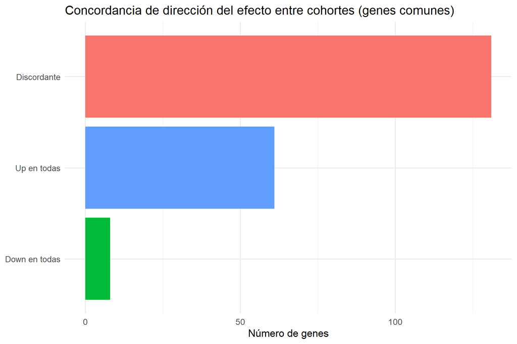

```r
cross_table %>%
  count(direction_concordant) %>%
  ggplot(aes(x = reorder(direction_concordant, n), y = n, fill = direction_concordant)) +
  geom_col(show.legend = FALSE) +
  coord_flip() +
  labs(
    title = "Concordancia de dirección del efecto entre cohortes (genes comunes)",
    x = NULL,
    y = "Número de genes"
  ) +
  theme_minimal(base_size = 13)
```

## 8.3 Scatter logFC GSE78220 vs GSE215868

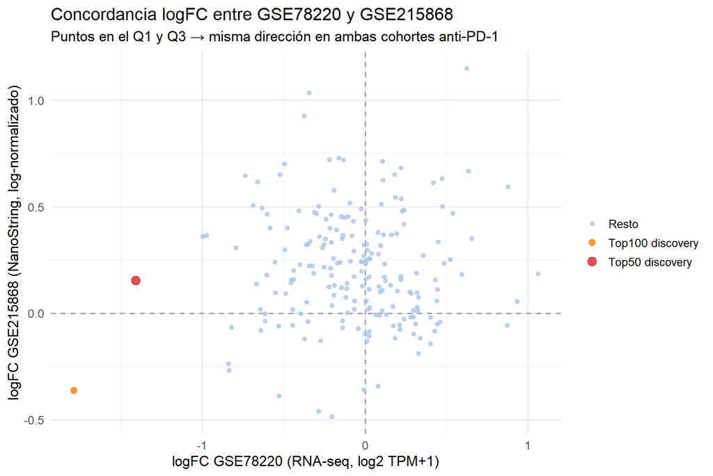

```r
if (all(c("logFC_GSE78220", "logFC_GSE215868") %in% colnames(cross_table))) {
  cross_table %>%
    filter(!is.na(logFC_GSE78220), !is.na(logFC_GSE215868)) %>%
    mutate(highlight = case_when(
      in_discovery_top50  ~ "Top50 discovery",
      in_discovery_top100 ~ "Top100 discovery",
      TRUE                ~ "Resto"
    )) %>%
    ggplot(aes(x = logFC_GSE78220, y = logFC_GSE215868,
               color = highlight, size = highlight)) +
    geom_hline(yintercept = 0, linetype = "dashed", color = "grey60") +
    geom_vline(xintercept = 0, linetype = "dashed", color = "grey60") +
    geom_point(alpha = 0.8) +
    scale_color_manual(values = c("Top50 discovery" = "#d62728",
                                  "Top100 discovery" = "#ff7f0e",
                                  "Resto"            = "#aec7e8")) +
    scale_size_manual(values  = c("Top50 discovery" = 3.5,
                                  "Top100 discovery" = 2.5,
                                  "Resto"            = 1.5)) +
    labs(
      title = "Concordancia logFC entre GSE78220 y GSE215868",
      subtitle = "Puntos en el Q1 y Q3 → misma dirección en ambas cohortes anti-PD-1",
      x = "logFC GSE78220 (RNA-seq, log2 TPM+1)",
      y = "logFC GSE215868 (NanoString, log-normalizado)",
      color = NULL, size = NULL
    ) +
    theme_minimal(base_size = 13)
}
```

# 9 Checklist final

```r
checks <- tibble(
  comprobacion = c(
    "Objeto integrado cargado para extraer genes comunes",
    "GSE78220 restringido a genes comunes",
    "GSE215868 restringido a genes comunes",
    "GSE211645 restringido a genes comunes",
    "DEA GSE78220 ejecutado",
    "DEA GSE215868 ejecutado",
    "Tabla cruzada construida",
    "Tabla cruzada guardada",
    "Cross-referencia con discovery realizada"
  ),
  estado = c(
    nrow(se_integrated) > 0,
    cohorts$GSE78220$n_genes > 0,
    cohorts$GSE215868$n_genes > 0,
    cohorts$GSE211645$n_genes > 0,
    !is.null(dea_list$GSE78220),
    !is.null(dea_list$GSE215868),
    nrow(cross_table) > 0,
    file.exists(file.path(output_dir, "cross_cohort_logFC_table.csv")),
    "in_discovery_top50" %in% colnames(cross_table)
  )
)

kable(checks, caption = "Checklist final del análisis de consistencia")
```

Checklist final del análisis de consistencia

| comprobacion | estado |
| --- | --- |
| Objeto integrado cargado para extraer genes comunes | TRUE |
| GSE78220 restringido a genes comunes | TRUE |
| GSE215868 restringido a genes comunes | TRUE |
| GSE211645 restringido a genes comunes | TRUE |
| DEA GSE78220 ejecutado | TRUE |
| DEA GSE215868 ejecutado | TRUE |
| Tabla cruzada construida | TRUE |
| Tabla cruzada guardada | TRUE |
| Cross-referencia con discovery realizada | TRUE |

```r
if (!all(checks$estado)) {
  stop("Alguno de los checks finales no se cumple.")
}
```

# 10 Conclusión metodológica

Este análisis evalúa si los efectos observados en el descubrimiento (GSE78220, transcriptoma completo) son consistentes en el subconjunto de genes comunes que comparten las tres cohortes tumorales.

Puntos clave de interpretación:

- **Las magnitudes de logFC no son directamente comparables** entre cohortes: GSE78220 usa log2(TPM+1) y las NanoString usan su propia escala logarítmica de normalización.
- **La dirección del efecto (signo del logFC) sí es comparable** entre cohortes y es el indicador principal de consistencia.
- Los genes concordantes en las tres cohortes son los candidatos más sólidos para la memoria, independientemente de si alcanzan significación estadística individual.
- GSE211645 (anti-CTLA-4) permite evaluar si la señal se generaliza a un mecanismo de checkpoint distinto.